# Health and Economic consequences due to weather events across the United States of America (1950 - 2011)

Alvaro Lozano Alonso

1/11/2021

# Synopsis

In this report we aim to explore the NOAA Storm Database and answer two questions: Which types of events are most harmful with respect to population health, and which types of events have the greatest economic consequences in the USA. The events in the database start in the year 1950 and end in November 2011. To answer the first questions, we analyzed the database, specifically, the variables `EVTYPE`, `FATALITIES` and `INJURIES`. And we found out that, by far, the worst event is the tornado, followed by excessive heat and flash food. To answer the second question, we analyzed the variables `EVTYPE`, `PROPDMG`, `CROPDMG`, `PROPDMGEXP` and `CROPDMGEXP`. In this case, data shows that floods cause the worst economic consequences, followed by hurricanes/typhoons and tornados.

# Libraries

First we need to load some handy libraries to process the data.

```r
library(dplyr)
library(reshape2)
library(ggplot2)
```

# Loading and Processing the Raw Data

## Loading data

We set our working directory and donwload the dataset from the [link](https://d396qusza40orc.cloudfront.net/repdata%2Fdata%2FStormData.csv.bz2). After doing so, we read the dataset into a new variable called `stormData`.

```r
setwd("~/Documents/Dokumente - MacBook Air/Data Science with R - Johns Hopkins University/Reproducible Research/JHU-Data_Science-Reproducible_Research_2")
if (!file.exists("StormData.csv.bz2")) {
  download.file("https://d396qusza40orc.cloudfront.net/repdata%2Fdata%2FStormData.csv.bz2", "StormData.csv.bz2")
}
downloadedDate <- file.info("StormData.csv.bz2")$ctime
stormData <- read.csv("StormData.csv.bz2")
print(paste("File was downloaded on", downloadedDate))
```

```
## [1] "File was downloaded on 2021-01-13 00:26:14"
```

## Overview

It is always useful to have an overview of the data.

```r
str(stormData)
```

```
## 'data.frame':    902297 obs. of  37 variables:
##  $ STATE__   : num  1 1 1 1 1 1 1 1 1 1 ...
##  $ BGN_DATE  : chr  "4/18/1950 0:00:00" "4/18/1950 0:00:00" "2/20/1951 0:00:00" "6/8/1951 0:00:00" ...
##  $ BGN_TIME  : chr  "0130" "0145" "1600" "0900" ...
##  $ TIME_ZONE : chr  "CST" "CST" "CST" "CST" ...
##  $ COUNTY    : num  97 3 57 89 43 77 9 123 125 57 ...
##  $ COUNTYNAME: chr  "MOBILE" "BALDWIN" "FAYETTE" "MADISON" ...
##  $ STATE     : chr  "AL" "AL" "AL" "AL" ...
##  $ EVTYPE    : chr  "TORNADO" "TORNADO" "TORNADO" "TORNADO" ...
##  $ BGN_RANGE : num  0 0 0 0 0 0 0 0 0 0 ...
##  $ BGN_AZI   : chr  "" "" "" "" ...
##  $ BGN_LOCATI: chr  "" "" "" "" ...
##  $ END_DATE  : chr  "" "" "" "" ...
##  $ END_TIME  : chr  "" "" "" "" ...
##  $ COUNTY_END: num  0 0 0 0 0 0 0 0 0 0 ...
```

[output cut: 23 more lines]

The variables that are going to be used in the analysis are:  
`EVTYPE`: The event type, for example: Tornado, Flood, High wind…  
`FATALITIES`: The number of deceased people in a particular event.  
`INJURIES`: The number of people that suffered injuries in a particular event.  
`PROPDMG`: The base number of the property damages occurred in a particular event.  
`PROPDMGEXP`: The exponent of the property damages occurred in a particular event. For example `K` as 1.000  
`CROPDMG`: The base number of the crop damages occurred in a particular event.  
`CROPDMGEXP`: The exponent of the crop damages occurred in a particular event. For example `B` as 1.000.000.000

## Processing the data: Events that are most harmful with respect to population health

To answer the first question (“Across the United States, which types of events (as indicated in the EVTYPE variable) are most harmful with respect to population health?”) we need to group all the observations by the event type and sum all the fatalities and injuries. Then, we sort them in descent order to find out which are the first 15 types of events that have the worst effect with respect to population health.

```r
populationHealth <- stormData %>% select(EVTYPE, FATALITIES, INJURIES) %>% group_by(EVTYPE) %>% summarise(FATALITIES = sum(FATALITIES), INJURIES = sum(INJURIES), .groups="drop") %>% filter(FATALITIES != 0 & INJURIES != 0) %>% arrange(desc(FATALITIES), desc(INJURIES))

# Create new variable to store the first 15 events
top15populationHealth <- head(populationHealth, 15)

# Set EVTYPE as factor variable so that plot is sort properly
top15populationHealth$EVTYPE <- factor(top15populationHealth$EVTYPE, levels=unique(top15populationHealth$EVTYPE))

# Prepare the data for the barplot
splitPopH <- melt(top15populationHealth, id.vars="EVTYPE")

# Create the plot
popHplot <- ggplot(splitPopH, aes(x=EVTYPE, y=value, fill=variable)) +
            geom_bar(position='dodge', stat='identity') +
            theme(axis.text.x=element_text(angle=90, hjust=1, vjust=.25), legend.title=element_blank()) +
            ylab("Fatalities & Injuries") +
            xlab("Event Type") +
            ggtitle("Total Fatalities and Injuries caused by Extreme Weather in the USA (1950 - 2011)")
```

## Processing the data: Events that have the greatest economic consequences

Before any calculations, we need to prepare the data. We create a new dataframe with the variables of interest. After that, we need to format the exponents.

```r
# Set a new variable that stores only the variables that are necessary
ecoConseq <- stormData %>% select(EVTYPE, PROPDMG, PROPDMGEXP, CROPDMG, CROPDMGEXP)

# Get the unique values for the PROPDMGEXP variable
unique(ecoConseq$PROPDMGEXP)
```

```
##  [1] "K" "M" ""  "B" "m" "+" "0" "5" "6" "?" "4" "2" "3" "h" "7" "H" "-" "1" "8"
```

As we can see, the exponents have characters that need to be formatted to operate. We format them as it follows:

```r
# Numeric exponent for PROPDMG
ecoConseq$PROPDMGEXP_NUM[is.na(ecoConseq$PROPDMGEXP)] <- 1
ecoConseq$PROPDMGEXP_NUM[ecoConseq$PROPDMGEXP == "?" & !is.na(ecoConseq$PROPDMGEXP)] <- 0
ecoConseq$PROPDMGEXP_NUM[ecoConseq$PROPDMGEXP == ""  & !is.na(ecoConseq$PROPDMGEXP)] <- 1
ecoConseq$PROPDMGEXP_NUM[ecoConseq$PROPDMGEXP == "+" & !is.na(ecoConseq$PROPDMGEXP)] <- 1
ecoConseq$PROPDMGEXP_NUM[ecoConseq$PROPDMGEXP == "-" & !is.na(ecoConseq$PROPDMGEXP)] <- 1
ecoConseq$PROPDMGEXP_NUM[ecoConseq$PROPDMGEXP == "0" & !is.na(ecoConseq$PROPDMGEXP)] <- 1
ecoConseq$PROPDMGEXP_NUM[ecoConseq$PROPDMGEXP == "1" & !is.na(ecoConseq$PROPDMGEXP)] <- 10
ecoConseq$PROPDMGEXP_NUM[ecoConseq$PROPDMGEXP == "2" & !is.na(ecoConseq$PROPDMGEXP)] <- 100
ecoConseq$PROPDMGEXP_NUM[ecoConseq$PROPDMGEXP == "3" & !is.na(ecoConseq$PROPDMGEXP)] <- 1000
ecoConseq$PROPDMGEXP_NUM[ecoConseq$PROPDMGEXP == "4" & !is.na(ecoConseq$PROPDMGEXP)] <- 10000
ecoConseq$PROPDMGEXP_NUM[ecoConseq$PROPDMGEXP == "5" & !is.na(ecoConseq$PROPDMGEXP)] <- 100000
ecoConseq$PROPDMGEXP_NUM[ecoConseq$PROPDMGEXP == "6" & !is.na(ecoConseq$PROPDMGEXP)] <- 1000000
ecoConseq$PROPDMGEXP_NUM[ecoConseq$PROPDMGEXP == "7" & !is.na(ecoConseq$PROPDMGEXP)] <- 10000000
ecoConseq$PROPDMGEXP_NUM[ecoConseq$PROPDMGEXP == "8" & !is.na(ecoConseq$PROPDMGEXP)] <- 100000000
ecoConseq$PROPDMGEXP_NUM[ecoConseq$PROPDMGEXP == "B" & !is.na(ecoConseq$PROPDMGEXP)] <- 1000000000
ecoConseq$PROPDMGEXP_NUM[ecoConseq$PROPDMGEXP == "H" & !is.na(ecoConseq$PROPDMGEXP)] <- 100
ecoConseq$PROPDMGEXP_NUM[ecoConseq$PROPDMGEXP == "h" & !is.na(ecoConseq$PROPDMGEXP)] <- 100
ecoConseq$PROPDMGEXP_NUM[ecoConseq$PROPDMGEXP == "K" & !is.na(ecoConseq$PROPDMGEXP)] <- 1000
ecoConseq$PROPDMGEXP_NUM[ecoConseq$PROPDMGEXP == "M" & !is.na(ecoConseq$PROPDMGEXP)] <- 1000000
ecoConseq$PROPDMGEXP_NUM[ecoConseq$PROPDMGEXP == "m" & !is.na(ecoConseq$PROPDMGEXP)] <- 1000000
```

```r
# Get the unique values for the CROPDMGEXP variable
unique(ecoConseq$CROPDMGEXP)
```

```
## [1] ""  "M" "K" "m" "B" "?" "0" "k" "2"
```

As we can see, the exponents have characters that need to be formatted to operate. We format them as it follows:

```r
## Numeric exponent for CROPDMG
ecoConseq$CROPDMGEXP_NUM[is.na(ecoConseq$CROPDMGEXP)] <- 1
ecoConseq$CROPDMGEXP_NUM[ecoConseq$CROPDMGEXP == "?" & !is.na(ecoConseq$CROPDMGEXP)] <- 0
ecoConseq$CROPDMGEXP_NUM[ecoConseq$CROPDMGEXP == ""  & !is.na(ecoConseq$CROPDMGEXP)] <- 1
ecoConseq$CROPDMGEXP_NUM[ecoConseq$CROPDMGEXP == "0" & !is.na(ecoConseq$CROPDMGEXP)] <- 1
ecoConseq$CROPDMGEXP_NUM[ecoConseq$CROPDMGEXP == "2" & !is.na(ecoConseq$CROPDMGEXP)] <- 100
ecoConseq$CROPDMGEXP_NUM[ecoConseq$CROPDMGEXP == "K" & !is.na(ecoConseq$CROPDMGEXP)] <- 1000
ecoConseq$CROPDMGEXP_NUM[ecoConseq$CROPDMGEXP == "k" & !is.na(ecoConseq$CROPDMGEXP)] <- 1000
ecoConseq$CROPDMGEXP_NUM[ecoConseq$CROPDMGEXP == "M" & !is.na(ecoConseq$CROPDMGEXP)] <- 1000000
ecoConseq$CROPDMGEXP_NUM[ecoConseq$CROPDMGEXP == "m" & !is.na(ecoConseq$CROPDMGEXP)] <- 1000000
ecoConseq$CROPDMGEXP_NUM[ecoConseq$CROPDMGEXP == "B" & !is.na(ecoConseq$CROPDMGEXP)] <- 1000000000
```

To answer the second question (“Across the United States, which types of events have the greatest economic consequences?”) we need to group all the observations by the event type and sum all the damages properly. Then, we sort them in descent order to find out which are the first 15 types of events that have the greatest economic consequences.

```r
# Calculate the damages cost
ecoConseq$CALPROPDMG <- ecoConseq$PROPDMG * ecoConseq$PROPDMGEXP_NUM
ecoConseq$CALCROPDMG <- ecoConseq$CROPDMG * ecoConseq$CROPDMGEXP_NUM

calEcoConseq <- ecoConseq %>% select(EVTYPE, CALPROPDMG, CALCROPDMG) %>% group_by(EVTYPE) %>% summarise(CALPROPDMG = sum(CALPROPDMG), CALCROPDMG = sum(CALCROPDMG), .groups="drop") %>% filter(CALPROPDMG != 0 & CALCROPDMG != 0) %>% arrange(desc(CALPROPDMG + CALCROPDMG))

# Create new variable to store the first 15 events
top15calEcoConseq <- head(calEcoConseq, 15)

# CALPROPDMG AND CALCROPDMG IN BILLIONS (US billions, i.e. 1.000.000.000)
top15calEcoConseq$CALPROPDMG <- top15calEcoConseq$CALPROPDMG / 1000000000
top15calEcoConseq$CALCROPDMG <- top15calEcoConseq$CALCROPDMG / 1000000000

# Set EVTYPE as factor variable so that plot is sort properly
top15calEcoConseq$EVTYPE <- factor(top15calEcoConseq$EVTYPE, levels=unique(top15calEcoConseq$EVTYPE))

# Prepare the data for the barplot
splitCEC <- melt(top15calEcoConseq, id.vars="EVTYPE")

# Create the plot
ecoConPlot <- ggplot(splitCEC, aes(x=EVTYPE, y=value, fill=variable)) +
              geom_bar(position='stack', stat='identity') +
              theme(axis.text.x=element_text(angle=90, hjust=1, vjust=.25), legend.title=element_blank()) +
              ylab("Damage (Billions of US Dollars)") +
              xlab("Event Type") +
              ggtitle("Total Crop and Property Damage caused by Extreme Weather in the USA (1950 - 2011)")
```

# Results

## Events that are most harmful with respect to population health

```r
top15populationHealth
```

```
## # A tibble: 15 x 3
##    EVTYPE            FATALITIES INJURIES
##    <fct>                  <dbl>    <dbl>
##  1 TORNADO                 5633    91346
##  2 EXCESSIVE HEAT          1903     6525
##  3 FLASH FLOOD              978     1777
##  4 HEAT                     937     2100
##  5 LIGHTNING                816     5230
##  6 TSTM WIND                504     6957
##  7 FLOOD                    470     6789
##  8 RIP CURRENT              368      232
##  9 HIGH WIND                248     1137
## 10 AVALANCHE                224      170
## 11 WINTER STORM             206     1321
## 12 RIP CURRENTS             204      297
## 13 HEAT WAVE                172      309
## 14 EXTREME COLD             160      231
## 15 THUNDERSTORM WIND        133     1488
```

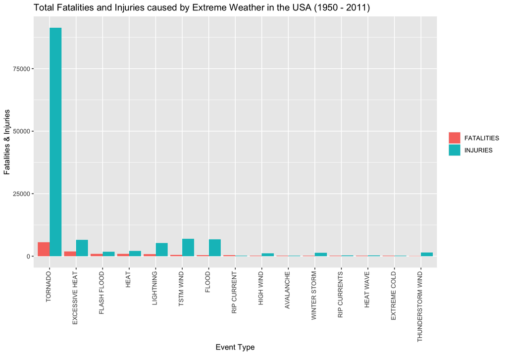

```r
popHplot
```

As we can see on the plot, the worst event is clearly the tornado, causing over 90.000 injuries and 5633 fatalities. It is followed by ecessive heat, flash flood, heat and lightning among others.

## Events that have the greatest economic consequences

```r
top15calEcoConseq
```

```
## # A tibble: 15 x 3
##    EVTYPE            CALPROPDMG CALCROPDMG
##    <fct>                  <dbl>      <dbl>
##  1 FLOOD                 145.     5.66
##  2 HURRICANE/TYPHOON      69.3    2.61
##  3 TORNADO                56.9    0.415
##  4 STORM SURGE            43.3    0.000005
##  5 HAIL                   15.7    3.03
##  6 FLASH FLOOD            16.8    1.42
##  7 DROUGHT                 1.05  14.0
##  8 HURRICANE              11.9    2.74
##  9 RIVER FLOOD             5.12   5.03
## 10 ICE STORM               3.94   5.02
## 11 TROPICAL STORM          7.70   0.678
## 12 WINTER STORM            6.69   0.0269
## 13 HIGH WIND               5.27   0.639
## 14 WILDFIRE                4.77   0.295
## 15 TSTM WIND               4.48   0.554
```

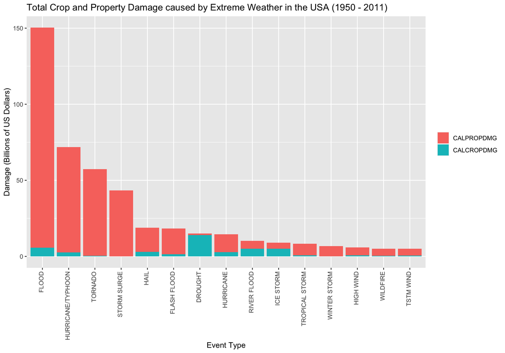

```r
ecoConPlot
```

Plot shows that the event that causes the total greatest economic consequences is the flood. It is followed by the hurricane/typhoon, tornado and storm surge. If we look at the economic consecuences due crop damages, we see that drought is the worst event.